# HW5 - Make Data Move

Søren Johansen

05/10/2020

## Opgave 1 - den danske kongerække

Jeg starter med at oprette en datafolder, hvori jeg indsætter med min kongerække-csv-fil.

```r
library(tidyverse)
library(here)
dir.create("data")
```

Off-screen har jeg nu flyttet min fil i datafolderen. Jeg indlæser den:

```r
dkkings <- read_csv("data/data_konger-csv.csv")
```

Inden vi kan lege med dataene grafisk tilføjer jeg en søjle med længden af kongernes/dronningens regeringstid.

```r
dkkings_duration <- dkkings %>%
  mutate(duration_reign = reignend_year - reignstart_year)
```

Jeg kigger lige om r har tilføjet søjlen ordentligt:

```r
glimpse(dkkings_duration)
```

```
## Rows: 54
## Columns: 10
## $ name            <chr> "Gorm den Gamle", "Harald I", "Svend I", "Harald II", …
## $ birthyear       <dbl> NA, NA, NA, NA, 995, 1020, 1024, NA, NA, NA, NA, 1056,…
## $ birthmonth      <dbl> NA, NA, NA, NA, NA, NA, NA, NA, NA, NA, NA, NA, NA, NA…
## $ birthday        <dbl> NA, NA, NA, NA, NA, NA, NA, NA, NA, NA, NA, NA, NA, NA…
## $ deathyear       <dbl> 958, 987, 1014, 1018, 1035, 1042, 1047, 1076, 1080, 10…
## $ deathmonth      <dbl> NA, NA, NA, NA, NA, NA, NA, 4, NA, 7, NA, NA, NA, 7, 8…
## $ deathday        <dbl> NA, NA, NA, NA, NA, NA, NA, 28, NA, 10, NA, NA, NA, 18…
## $ reignstart_year <dbl> 936, 958, 987, 1014, 1018, 1035, 1042, 1047, 1074, 108…
## $ reignend_year   <dbl> 958, 987, 1014, 1018, 1035, 1042, 1047, 1074, 1080, 10…
## $ duration_reign  <dbl> 22, 29, 27, 4, 17, 7, 5, 27, 6, 6, 9, 8, 30, 3, 9, 11,…
```

Konsollen medgiver, at det har den. Jeg var heldig at maskineriet læste værdierne i min csv-fil som tal, og ikke som bogstaver. Så blev jeg sparet for noget besværd.

Nu kan jeg eksperimentere med at plotte.

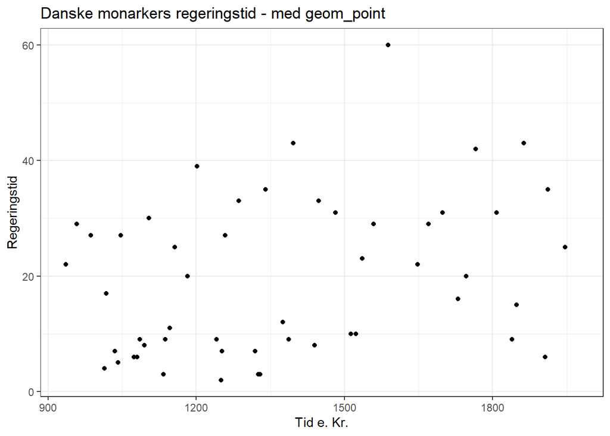

```r
dkkings_duration %>%
  ggplot(aes(x = reignstart_year, y = duration_reign))+
  geom_point()+
  labs(title = "Danske monarkers regeringstid - med geom_point",
       x = "Tid e. Kr.",
       y = "Regeringstid")+
  theme_bw()
```

Maskinen brokker sig over, at der er én værdi den ikke kunne finde. Denne værdi er dronning Margrethe II’s regeringstid, da den endnu ikke kan beregnes endegyldigt. Sagt på en anden måde er værdien for hendes regeringstids slutning angivet med “NA” i csv-filen, hvorfor r ikke kunne beregne hendes regeringstid i ovenstående mutate-kommando. Dvs. plottet angiver monarkernes regeringstid fra og med Gorm den Gamle til og med Frederik IX.

Vi kan også lave ovenstående plot som linjediagram:

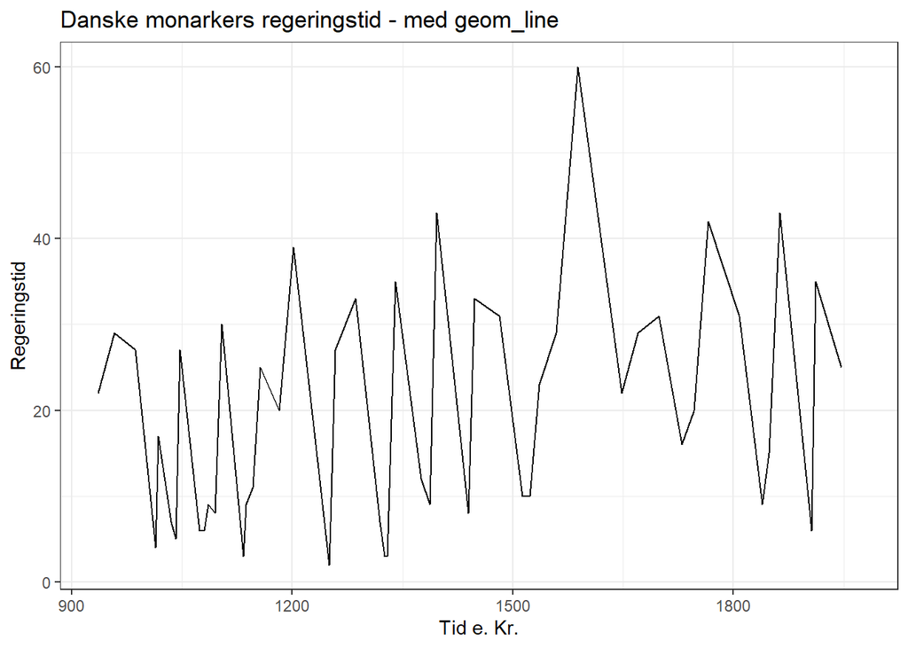

```r
dkkings_duration %>%
  ggplot(aes(x = reignstart_year, y = duration_reign))+
  geom_line()+
  labs(title = "Danske monarkers regeringstid - med geom_line",
       x = "Tid e. Kr.",
       y = "Regeringstid")+
  theme_bw()
```

Og som sagt, så gjort. Christian IV’s alt for mange år på tronen er virkelig synlig hér.

Adela byder os også at udføre øvelsen med geom_smooth, så lad os det.

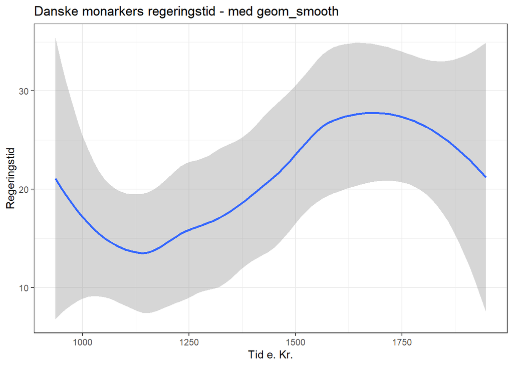

```r
dkkings_duration %>%
  ggplot(aes(x = reignstart_year, y = duration_reign))+
  geom_smooth()+
  labs(title = "Danske monarkers regeringstid - med geom_smooth",
       x = "Tid e. Kr.",
       y = "Regeringstid")+
  theme_bw()
```

Maskinen tegner vist med geom_smooth en tendenslinje for de danske monarkers regeringstider. Med så blandede regeringstider tror jeg næppe at sådan en tendenskurve er noget værd.

# Opgave 2

## Explore global development with R

Today, you will load a filtered gapminder dataset - with a subset of data on global development from 1952 - 2007 in increments of 5 years - to capture the period between the Second World War and the Global Financial Crisis.

**Your task: Explore the data and visualise it in both static and animated ways, providing answers and solutions to 7 questions/tasks below.**

## Get the necessary packages

First, start with installing the relevant packages ‘tidyverse’, ‘gganimate’, and ‘gapminder’.

## Look at the data and tackle the tasks

First, see which specific years are actually represented in the dataset and what variables are being recorded for each country. Note that when you run the cell below, Rmarkdown will give you two results - one for each line - that you can flip between.

```r
str(gapminder)
```

```
## tibble [1,704 × 6] (S3: tbl_df/tbl/data.frame)
##  $ country  : Factor w/ 142 levels "Afghanistan",..: 1 1 1 1 1 1 1 1 1 1 ...
##  $ continent: Factor w/ 5 levels "Africa","Americas",..: 3 3 3 3 3 3 3 3 3 3 ...
##  $ year     : int [1:1704] 1952 1957 1962 1967 1972 1977 1982 1987 1992 1997 ...
##  $ lifeExp  : num [1:1704] 28.8 30.3 32 34 36.1 ...
##  $ pop      : int [1:1704] 8425333 9240934 10267083 11537966 13079460 14880372 12881816 13867957 16317921 22227415 ...
##  $ gdpPercap: num [1:1704] 779 821 853 836 740 ...
```

```r
unique(gapminder$year)
```

```
##  [1] 1952 1957 1962 1967 1972 1977 1982 1987 1992 1997 2002 2007
```

```r
head(gapminder)
```

```
## # A tibble: 6 × 6
##   country     continent  year lifeExp      pop gdpPercap
##   <fct>       <fct>     <int>   <dbl>    <int>     <dbl>
## 1 Afghanistan Asia       1952    28.8  8425333      779.
## 2 Afghanistan Asia       1957    30.3  9240934      821.
## 3 Afghanistan Asia       1962    32.0 10267083      853.
## 4 Afghanistan Asia       1967    34.0 11537966      836.
## 5 Afghanistan Asia       1972    36.1 13079460      740.
## 6 Afghanistan Asia       1977    38.4 14880372      786.
```

The dataset contains information on each country in the sampled year, its continent, life expectancy, population, and GDP per capita.

Let’s plot all the countries in 1952.

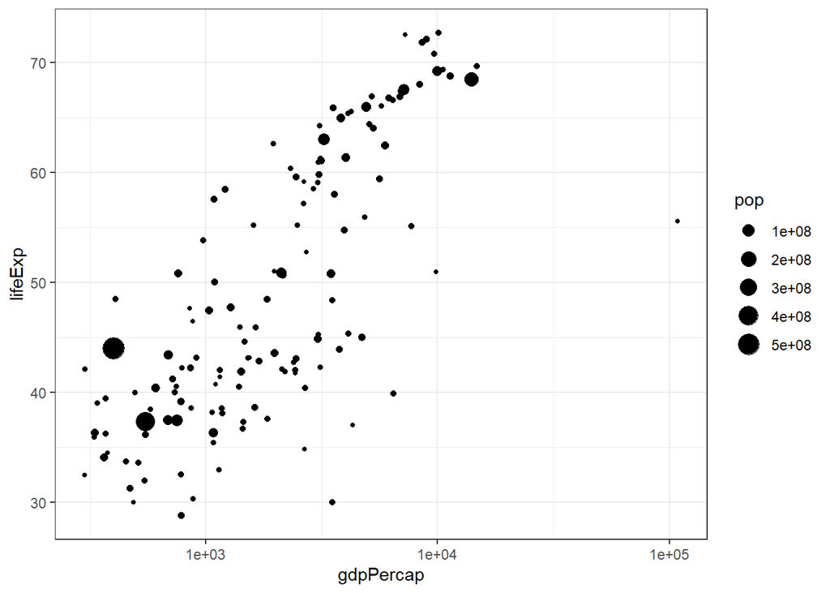

```r
theme_set(theme_bw())  # set theme to white background for better visibility

ggplot(subset(gapminder, year == 1952), aes(gdpPercap, lifeExp, size = pop)) +
  geom_point() +
  scale_x_log10()
```

We see an interesting spread with an outlier to the right. Answer the following questions, please:

1. *Why does it make sense to have a log10 scale on x axis?*

**Fordi der er så stor forskel på landenes GDP per capita, at x-aksen ville fortage sig i uendeligheden, hvis ikke man komprimerer den lidt ved at angive den med en log-funktion.**

2. *Who is the outlier (the richest country in 1952 - far right on x axis)?*

**Det finder vi lige ud af:**

```r
gapminder %>%
  filter(year == 1952) %>%
  arrange(desc(gdpPercap))
```

```
## # A tibble: 142 × 6
##    country        continent  year lifeExp       pop gdpPercap
##    <fct>          <fct>     <int>   <dbl>     <int>     <dbl>
##  1 Kuwait         Asia       1952    55.6    160000   108382.
##  2 Switzerland    Europe     1952    69.6   4815000    14734.
##  3 United States  Americas   1952    68.4 157553000    13990.
##  4 Canada         Americas   1952    68.8  14785584    11367.
##  5 New Zealand    Oceania    1952    69.4   1994794    10557.
##  6 Norway         Europe     1952    72.7   3327728    10095.
##  7 Australia      Oceania    1952    69.1   8691212    10040.
##  8 United Kingdom Europe     1952    69.2  50430000     9980.
##  9 Bahrain        Asia       1952    50.9    120447     9867.
## 10 Denmark        Europe     1952    70.8   4334000     9692.
## # ℹ 132 more rows
```

**Maskinen siger Kuwait, så det siger jeg.**

Next, you can generate a similar plot for 2007 and compare the differences

```r
gapminder
```

```
## # A tibble: 1,704 × 6
##    country     continent  year lifeExp      pop gdpPercap
##    <fct>       <fct>     <int>   <dbl>    <int>     <dbl>
##  1 Afghanistan Asia       1952    28.8  8425333      779.
##  2 Afghanistan Asia       1957    30.3  9240934      821.
##  3 Afghanistan Asia       1962    32.0 10267083      853.
##  4 Afghanistan Asia       1967    34.0 11537966      836.
##  5 Afghanistan Asia       1972    36.1 13079460      740.
##  6 Afghanistan Asia       1977    38.4 14880372      786.
##  7 Afghanistan Asia       1982    39.9 12881816      978.
##  8 Afghanistan Asia       1987    40.8 13867957      852.
##  9 Afghanistan Asia       1992    41.7 16317921      649.
## 10 Afghanistan Asia       1997    41.8 22227415      635.
## # ℹ 1,694 more rows
```

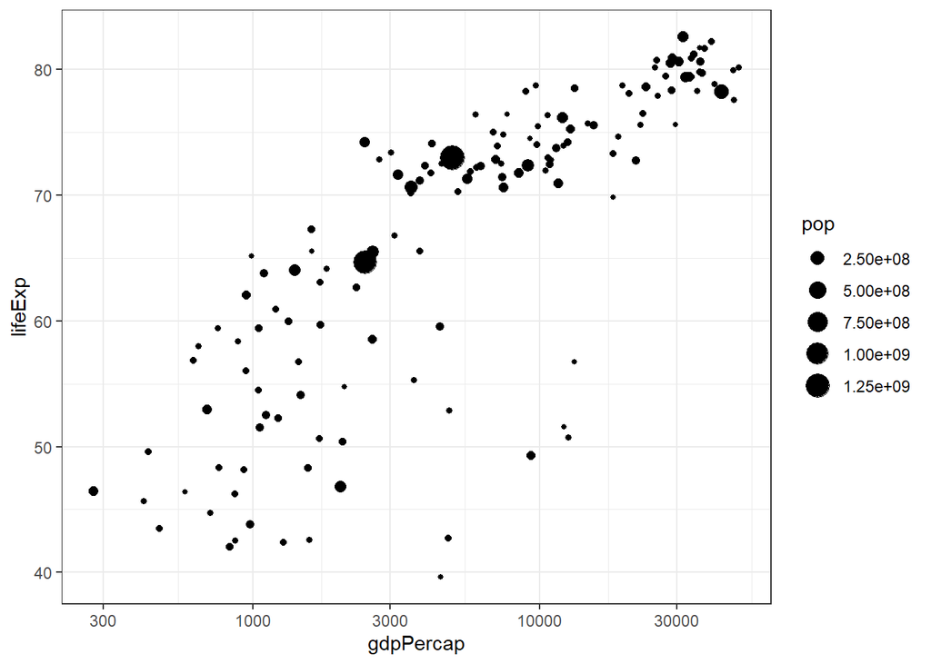

```r
ggplot(subset(gapminder, year == 2007), aes(gdpPercap, lifeExp, size = pop)) +
  geom_point() +
  scale_x_log10()
```

The black bubbles are a bit hard to read, the comparison would be easier with a bit more visual differentiation.

Tasks:

3. *Differentiate the **continents** by color, and fix the axis labels and units to be more legible (**Hint**: the 2.50e+08 is so called “scientific notation”, which you might want to eliminate)*
4. *What are the five richest countries in the world in 2007?*

**Vi prøver at forbedre diagrammet.**

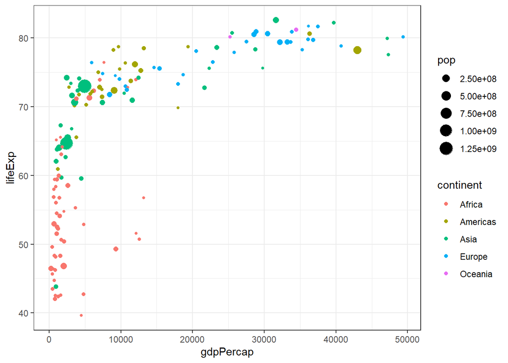

```r
ggplot(subset(gapminder, year == 2007), aes(colour = continent, gdpPercap, lifeExp, size = pop)) +
  geom_point() +
  scale_x_continuous()
```

**Og her er de 5 rigeste lande.**

```r
gapminder %>%
  filter(year == 2007) %>%
  arrange(desc(gdpPercap))
```

```
## # A tibble: 142 × 6
##    country          continent  year lifeExp       pop gdpPercap
##    <fct>            <fct>     <int>   <dbl>     <int>     <dbl>
##  1 Norway           Europe     2007    80.2   4627926    49357.
##  2 Kuwait           Asia       2007    77.6   2505559    47307.
##  3 Singapore        Asia       2007    80.0   4553009    47143.
##  4 United States    Americas   2007    78.2 301139947    42952.
##  5 Ireland          Europe     2007    78.9   4109086    40676.
##  6 Hong Kong, China Asia       2007    82.2   6980412    39725.
##  7 Switzerland      Europe     2007    81.7   7554661    37506.
##  8 Netherlands      Europe     2007    79.8  16570613    36798.
##  9 Canada           Americas   2007    80.7  33390141    36319.
## 10 Iceland          Europe     2007    81.8    301931    36181.
## # ℹ 132 more rows
```

**De 5 rigeste lande anno 2007 er Norge, Kuwait, Singapore, de Forenede Stater og Irland (mon de tager Guiness som valuta?)**

## Make it move!

The comparison would be easier if we had the two graphs together, animated. We have a lovely tool in R to do this: the `gganimate` package. Beware that there may be other packages your operating system needs in order to glue interim images into an animation or video. Read the messages when installing the package.

### Option 2 Animate using transition_time()

This option smoothes the transition between different ‘frames’, because it interpolates and adds transitional years where there are gaps in the timeseries data.

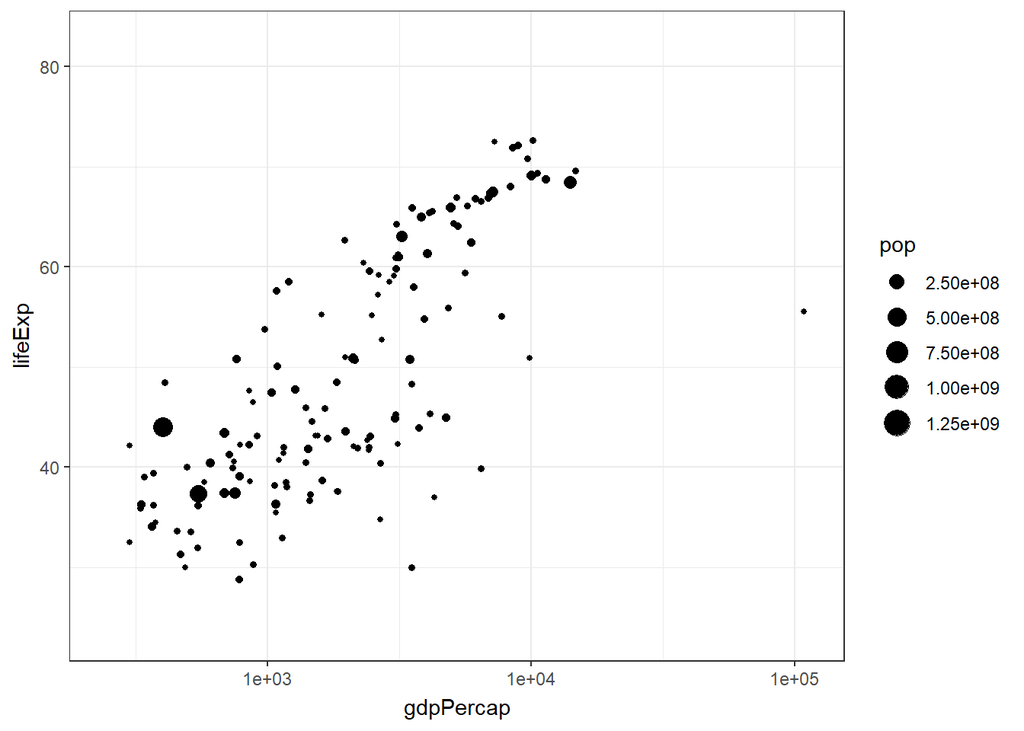

```r
anim2 <- ggplot(gapminder, aes(gdpPercap, lifeExp, size = pop)) +
  geom_point() +
  scale_x_log10() + # convert x to log scale
  transition_time(year)

anim2
```

Now, choose one of the animation options and get it to work. You may need to troubleshoot your installation of `gganimate` and other packages

5. *Can you add a title to one or both of the animations above that will change* *in sync with the animation?* *(**Hint**: search labeling for `transition_states()` and `transition_time()` functions respectively)*

**Vi tilføjer en titel.**

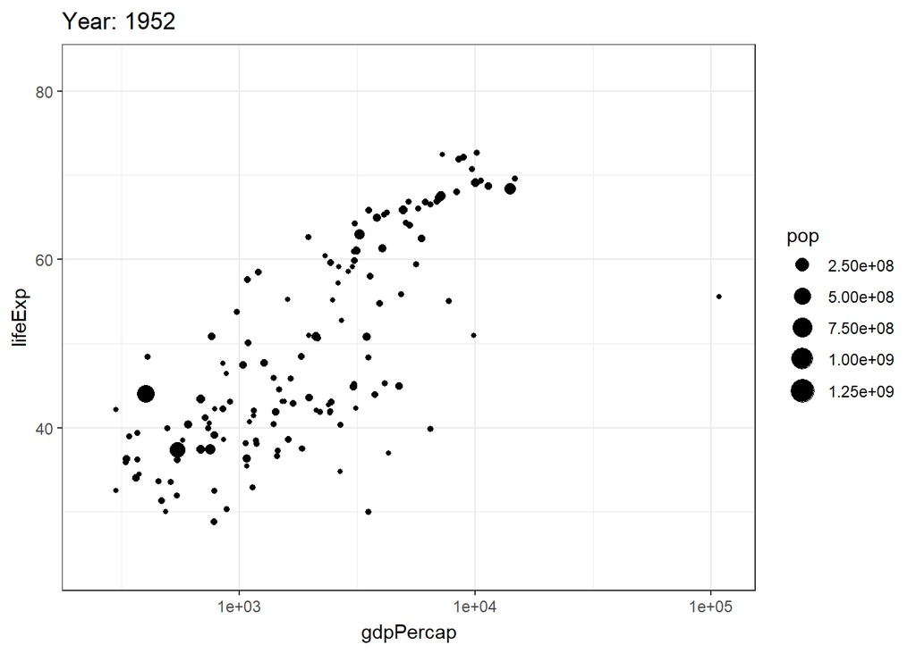

```r
anim2_med_titel <- ggplot(gapminder, aes(gdpPercap, lifeExp, size = pop)) +
  geom_point() +
  scale_x_log10() + # convert x to log scale
  transition_time(year) +
  labs(title = "Year: {frame_time}")

anim2_med_titel
```

6. *Can you made the axes’ labels and units more readable? Consider expanding the abreviated lables as well as the scientific notation in the legend and x axis to whole numbers.*

**Og vi leger videre.**

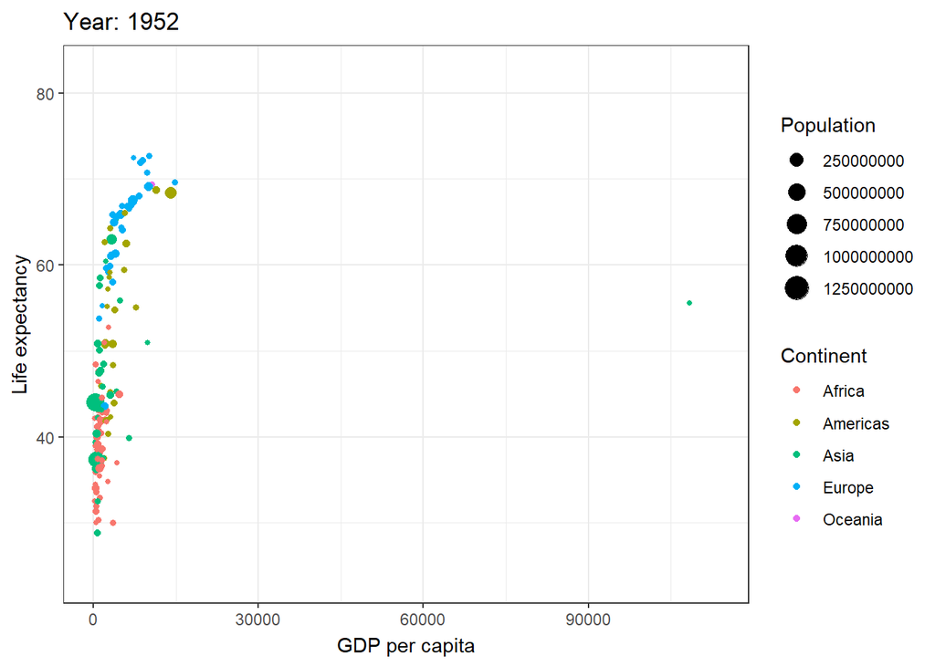

```r
# Jeg læste mig på nettet frem til, at man kan tvinge r til at droppe det pjat med scientific notation ved at molester- æh, pille ved systemets scipen-værdi. Jeg sætter min til 10000, det bør virke.

options(scipen = 10000)

# Nu bør det virke
anim2_med_hele_svineriet <- ggplot(gapminder, aes(colour = continent, gdpPercap, lifeExp, size = pop)) +
  geom_point() +
  scale_x_continuous() +
  transition_time(year) +
  labs(title = "Year: {frame_time}",
       x = "GDP per capita",
       y = "Life expectancy",
       size = "Population",
       colour = "Continent")

anim2_med_hele_svineriet
```

7. *Come up with a question you want to answer using the gapminder data and write it down. Then, create a data visualisation that answers the question and explain how your visualization answers the question. (Example: you wish to see what was mean life expectancy across the continents in the year you were born versus your parents’ birth years). [Hint: if you wish to have more data than is in the filtered gapminder, you can load either the `gapminder_unfiltered` dataset and download more at https://www.gapminder.org/data/ ]*

**Mon man kan lave en animation i stil med den i 6’eren, men hvori man kun sammenligner Tyskland og Danmark? Det kunne f.eks. være med henblik på at undersøge, om Tyskland “overhaler” Danmark på levealder på et tidspunkt.**

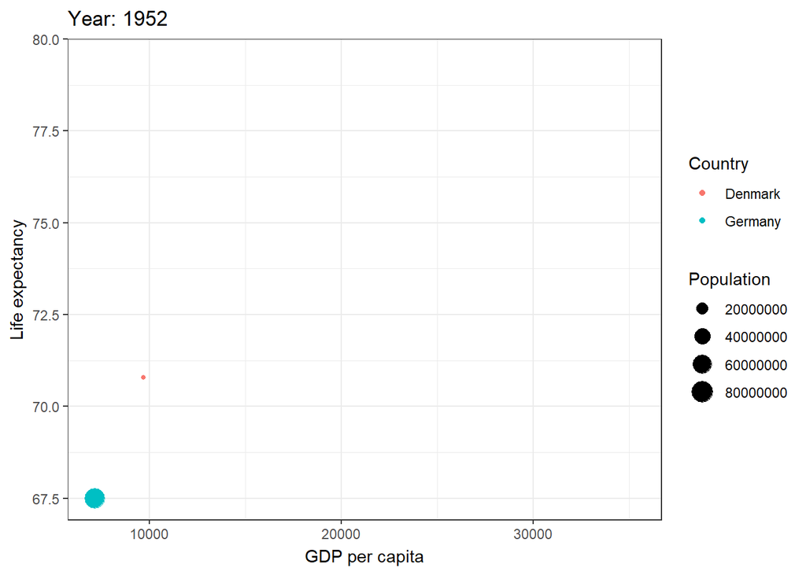

```r
# Jeg må nok hellere lave et nyt datasæt hvori Danmark og Tyskland er de eneste bestanddele
DKogDE <- gapminder %>%
  filter(country %in% c("Denmark", "Germany"))

# Vi animerer nu på samme vis som i opg. 6
anim2_DKogDE <- ggplot(DKogDE, aes(colour = country, gdpPercap, lifeExp, size = pop)) +
  geom_point() +
  scale_x_continuous() +
  transition_time(year) +
  labs(title = "Year: {frame_time}",
       x = "GDP per capita",
       y = "Life expectancy",
       size = "Population",
       colour = "Country")

anim2_DKogDE
```

**Vi kan se, at Tyskland overhaler Danmark mht. gennemsnitlig levealder i 80’erne. Pudsigt.**